# DPWH Budget Analysis

Office of the Secretary — Long-Run Appropriations

AJ Montesa / People's Budget Coalition

24 August 2026

# 1 Overview

This first section profiles the long-run budget of the **DPWH Office of the Secretary**: a (still incomplete) time series of the **NEP**, **GAA**, and **Actual Obligations** running back to 1988. Three views are shown — the **nominal** trend, the department's **share of the national budget**, and the **real (inflation-adjusted)** trend in constant 2018 prices.

All figures throughout this document are drawn from the National Expenditure Program (NEP), General Appropriations Act (GAA), and related budget documents published by the Department of Budget and Management (DBM).

A few conventions:

- Amounts are reported in **thousand pesos**; everything below is rescaled to **PHP billions** (`/ 1e6`).
- The headline series is **New + Automatic Appropriations** (the full agency budget, including automatic items). This is also the numerator used for the share of the national budget.
- Points mark **years with observed data**; the connecting line is interpolated, so visible gaps flag where encoding is still pending.

# 2 The Long View: DPWH Appropriations Since 1988

The four views below track the DPWH Office of the Secretary's budget across nearly four decades — in nominal pesos, as a share of the national budget, in inflation-adjusted terms, and in a single reference table — before the rest of the document turns to the program, item, and district-level detail of recent years.

## 2.1 Nominal Trend

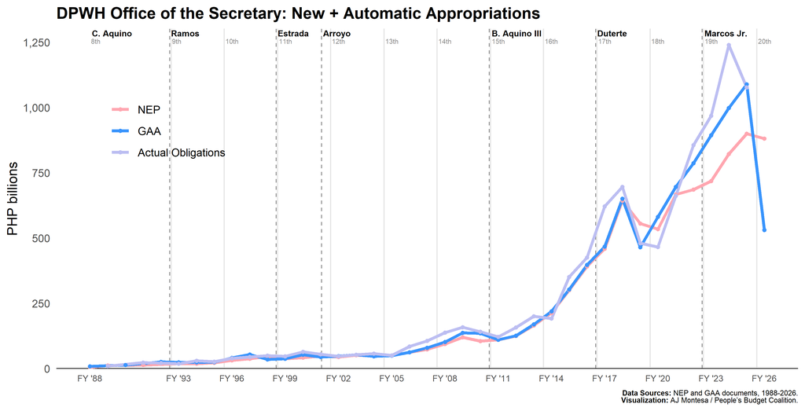

In nominal terms the DPWH OSec budget climbs steeply from the mid-2010s. Two deviations from the usual NEP-to-GAA pattern stand out and are worth raising in hearings: the **2019 GAA fell below the NEP** (the year of the ₱95.4B line-item veto; a smaller ₱26.1B veto also trimmed the 2025 GAA), and the **2026 GAA drops sharply below its NEP** — the reverse of the usual upward realignment seen in most other years.

## 2.2 Share of the National Budget

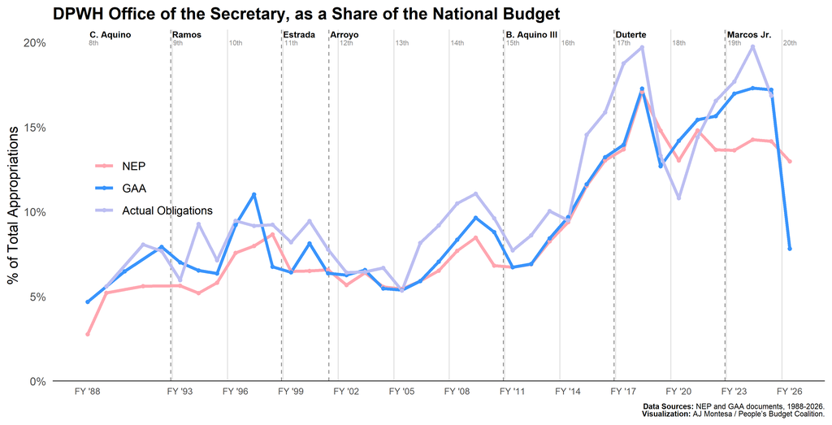

The share view rescales the same money against the size of the whole budget. The department's footprint roughly **doubles from ~6-8% (1990s-2000s) to a mid-teens share** in the latest years — evidence that DPWH's expansion outpaced overall budget growth, not merely tracked it. The 2026 NEP-to-GAA gap reappears here as a one-year contraction in the GAA share.

## 2.3 Real Trend (Inflation-Adjusted)

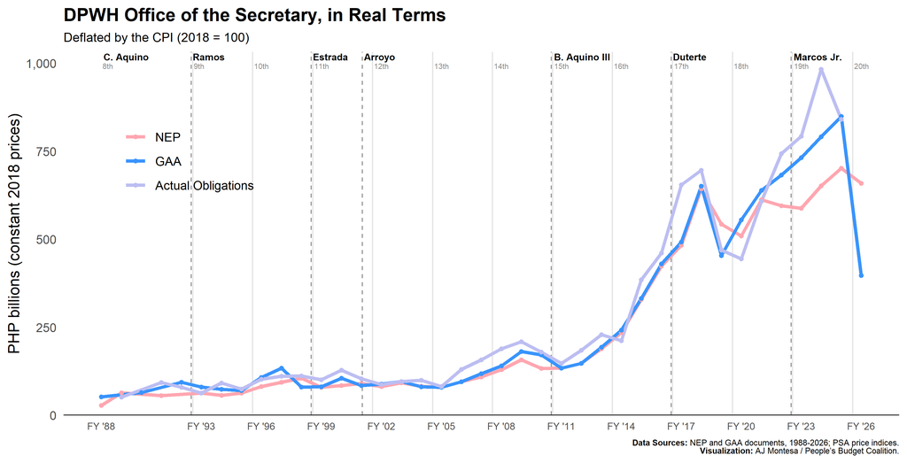

## 2.4 Summary Table

DPWH Office of the Secretary, New + Automatic Appropriations (PHP billions unless noted)

| FY | NEP | GAA | Actual Oblig. | Realignment (GAA-NEP) | DPWH Share (GAA) | GAA, real 2018 |
| --- | --- | --- | --- | --- | --- | --- |
| 2026 | 881.3 | 530.9 | -- | -350.4 | 7.8% | 396.8 |
| 2025 | 900.0 | 1,088.8 | 1,077.2 | 188.8 | 17.2% | 849.4 |
| 2024 | 822.2 | 997.9 | 1,239.7 | 175.7 | 17.3% | 791.3 |
| 2023 | 718.4 | 894.2 | 967.9 | 175.8 | 17.0% | 731.9 |
| 2022 | 686.1 | 786.6 | 856.5 | 100.5 | 15.7% | 682.3 |
| 2021 | 667.3 | 695.7 | 662.2 | 28.3 | 15.4% | 638.6 |
| 2020 | 534.3 | 581.7 | 466.1 | 47.4 | 14.2% | 554.9 |
| 2019 | 555.7 | 464.6 | 480.5 | -91.1 | 12.7% | 453.8 |
| 2018 | 643.3 | 650.9 | 696.3 | 7.6 | 17.3% | 650.9 |
| 2017 | 458.6 | 467.7 | 621.9 | 9.1 | 14.0% | 492.2 |
| 2016 | 391.2 | 397.1 | 425.8 | 5.9 | 13.2% | 429.9 |
| 2015 | 300.5 | 303.2 | 351.3 | 2.6 | 11.6% | 332.3 |
| 2014 | 213.0 | 219.3 | 191.8 | 6.4 | 9.7% | 242.0 |
| 2013 | 165.6 | 169.3 | 200.6 | 3.8 | 8.4% | 193.6 |
| 2012 | 125.5 | 125.7 | 157.6 | 0.2 | 6.9% | 147.5 |
| 2011 | 110.6 | 110.6 | 122.0 | 0.0 | 6.7% | 133.8 |
| 2010 | 105.3 | 135.6 | 141.8 | 30.3 | 8.8% | 171.8 |
| 2009 | 120.0 | 137.5 | 158.8 | 17.5 | 9.6% | 180.8 |
| 2008 | 94.5 | 102.4 | 137.9 | 8.0 | 8.3% | 140.4 |
| 2007 | 73.6 | 79.5 | 106.3 | 5.9 | 7.1% | 117.9 |
| 2006 | 62.3 | 62.3 | 85.3 | 0.0 | 5.9% | 95.1 |
| 2005 | 49.5 | 49.5 | 50.7 | 0.0 | 5.4% | 79.6 |
| 2004 | 48.2 | 47.2 | 57.9 | -1.0 | 5.5% | 81.0 |
| 2003 | 51.5 | 53.2 | 53.3 | 1.7 | 6.6% | 95.7 |
| 2002 | 44.3 | 48.3 | 47.6 | 3.9 | 6.3% | 88.8 |
| 2001 | 47.7 | 44.6 | 55.1 | -3.1 | 6.4% | 84.2 |
| 2000 | 42.4 | 52.9 | 64.5 | 10.5 | 8.1% | 105.3 |
| 1999 | 37.6 | 38.1 | 47.6 | 0.5 | 6.4% | 80.9 |
| 1998 | 46.8 | 35.7 | 49.7 | -11.1 | 6.8% | 80.4 |
| 1997 | 38.0 | 54.4 | 45.1 | 16.4 | 11.0% | 134.0 |
| 1996 | 31.5 | 41.1 | 39.4 | 9.7 | 9.2% | 107.1 |
| 1995 | 22.4 | 25.0 | 26.6 | 2.6 | 6.4% | 70.4 |
| 1994 | 18.8 | 24.4 | 30.4 | 5.6 | 6.5% | 73.5 |
| 1993 | 18.6 | 23.8 | 18.7 | 5.2 | 7.0% | 80.6 |
| 1992 | -- | 26.0 | 22.0 | -- | 7.9% | 94.1 |
| 1991 | 14.3 | -- | 23.7 | -- | -- | -- |
| 1990 | -- | 13.7 | -- | -- | 6.5% | 64.3 |
| 1989 | 12.0 | -- | 9.7 | -- | -- | -- |
| 1988 | 4.7 | 8.9 | -- | 4.2 | 4.7% | 52.7 |

# 3 The DPWH Budget by Program

DPWH organises its budget into eight **programs**. Consistent program labelling only begins with the **2018 budget**, so this section runs 2018-2026. These amounts are reported in **pesos** and are rescaled to **PHP billions** (`/ 1e9`). All figures are **New Appropriations** (the program totals reconcile to the New-Appropriations column used in Section 1).

## 3.1 Composition Over Time

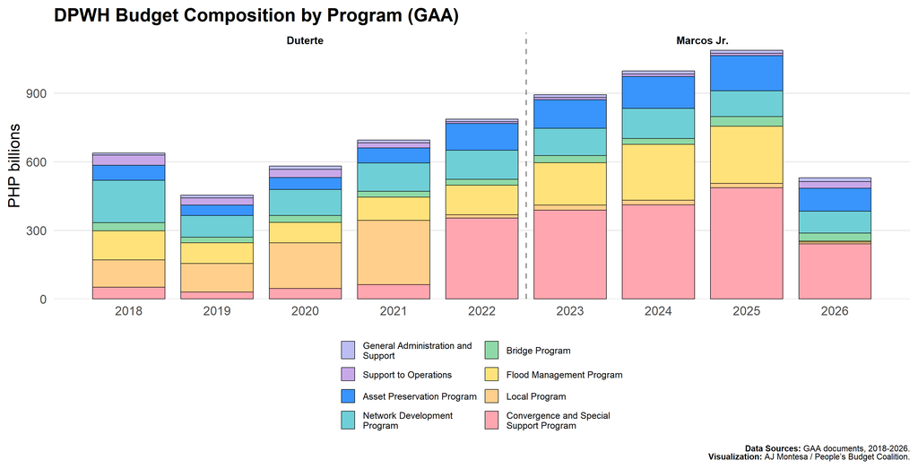

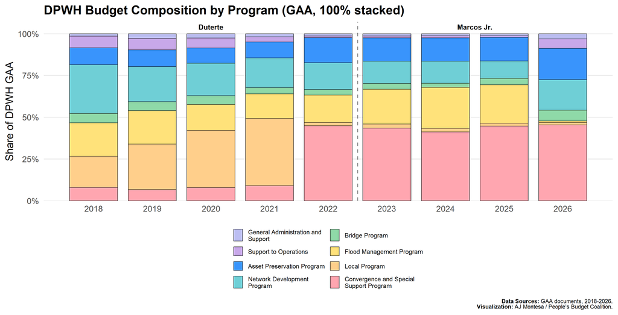

GAA by Program, PHP billions

| Program | 2027 | 2026 | 2025 | 2024 | 2023 | 2022 | 2021 | 2020 | 2019 | 2018 |
| --- | --- | --- | --- | --- | --- | --- | --- | --- | --- | --- |
| General Administration and Support | NA | 16.6 | 13.3 | 12.8 | 12.6 | 10.4 | 12.8 | 15.0 | 12.6 | 9.5 |
| Support to Operations | NA | 29.6 | 10.3 | 11.7 | 9.8 | 8.3 | 21.6 | 34.8 | 31.5 | 44.5 |
| Asset Preservation Program | NA | 99.4 | 154.1 | 139.0 | 124.6 | 117.5 | 66.0 | 52.9 | 45.5 | 65.0 |
| Network Development Program | NA | 96.8 | 112.7 | 132.3 | 119.2 | 127.0 | 124.5 | 113.4 | 95.3 | 185.5 |
| Bridge Program | NA | 34.1 | 42.6 | 24.8 | 31.2 | 25.4 | 25.4 | 30.2 | 24.3 | 35.7 |
| Flood Management Program | NA | 4.8 | 249.8 | 244.6 | 185.8 | 129.0 | 101.8 | 90.1 | 90.7 | 127.7 |
| Local Program | NA | 7.8 | 18.7 | 20.6 | 21.7 | 15.4 | 280.6 | 198.8 | 123.9 | 119.0 |
| Convergence and Special Support Program | NA | 240.5 | 486.2 | 411.0 | 388.3 | 352.8 | 62.1 | 45.7 | 30.3 | 51.0 |

## 3.2 NEP vs GAA and Realignments

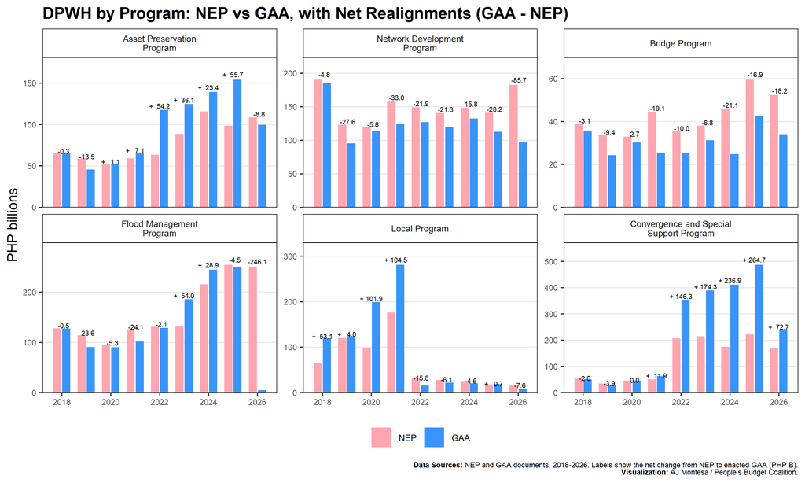

The same realignments read most cleanly as a matrix — each cell is the net move from the President's proposal (NEP) to the enacted law (GAA), with **blue = increases** and **red = cuts**:

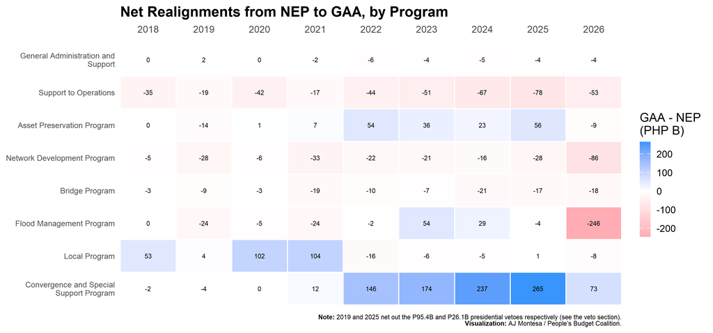

Net Realignment (GAA - NEP) by Program, PHP billions

| Program | 2026 | 2025 | 2024 | 2023 | 2022 | 2021 | 2020 | 2019 | 2018 |
| --- | --- | --- | --- | --- | --- | --- | --- | --- | --- |
| General Administration and Support | -3.9 | -4.3 | -4.6 | -3.5 | -6.0 | -2.4 | 0.0 | 2.1 | 0.1 |
| Support to Operations | -52.8 | -78.4 | -67.5 | -50.9 | -44.1 | -16.6 | -41.7 | -18.5 | -34.9 |
| Asset Preservation Program | -8.8 | 55.7 | 23.4 | 36.1 | 54.2 | 7.1 | 1.1 | -13.5 | -0.3 |
| Network Development Program | -85.7 | -28.2 | -15.8 | -21.3 | -21.9 | -33.0 | -5.8 | -27.6 | -4.8 |
| Bridge Program | -18.2 | -16.9 | -21.1 | -6.8 | -10.0 | -19.1 | -2.7 | -9.4 | -3.1 |
| Flood Management Program | -246.1 | -4.5 | 28.9 | 54.0 | -2.1 | -24.1 | -5.3 | -23.6 | -0.5 |
| Local Program | -7.6 | 0.7 | -4.6 | -6.1 | -15.8 | 104.5 | 101.9 | 4.0 | 53.1 |
| Convergence and Special Support Program | 72.7 | 264.7 | 236.9 | 174.3 | 146.3 | 11.9 | 0.0 | -3.9 | -2.0 |

# 4 Inside the Programs: Sub-Programs and Line Items

For readability, line items that the budget splits only by road class — the separate *Primary Roads*, *Secondary Roads* and *Tertiary Roads* versions of Preventive Maintenance, Road Widening, and a few others — are combined here into a single item each.

## 4.1 What's Inside the Major Programs

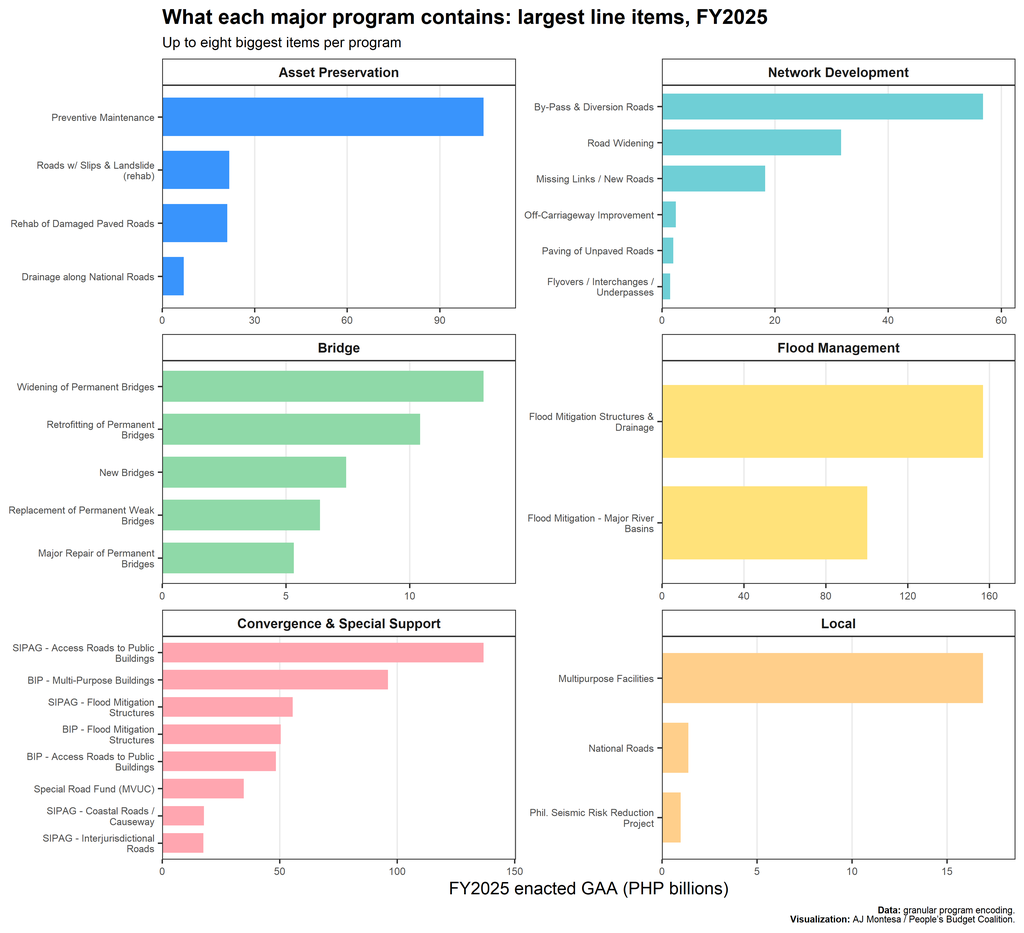

The contents follow the department's core mandates, with two important exceptions:

- **Asset Preservation** is road *upkeep*: preventive maintenance of primary, secondary and tertiary roads, plus rehabilitation of roads damaged by slips, landslides and disasters.
- **Network Development** is road *expansion*: road widening, by-pass and diversion roads, missing links and new roads, flyovers and interchanges.
- **Bridge** is exactly that — construction, replacement, widening and retrofitting of bridges.
- **Flood Management** is the government's headline flood line: construction and rehabilitation of flood-mitigation structures and drainage, including works along major river basins.
- **Convergence & Special Support** is the outlier — not a single purpose but a **basket** of two sub-programs, **SIPAG** and **BIP**, whose items are access roads to public buildings, multi-purpose buildings, *and their own flood- mitigation structures*. Much of what looks like "convergence" spending is thus district road-building, construction, and flood control under a different label.
- **Local Program** historically carried the same district works (local roads, multipurpose facilities, flood control and drainage) before FY2022, when most of it migrated into Convergence.

The key takeaway is that **flood-control money is spread across at least three programs** — the Flood Management Program, the SIPAG/BIP flood-mitigation items inside Convergence, and the Local Program's flood-control line — which is part of why the total was so hard to see, and so easy to inflate, before the FY2026 reckoning.

## 4.2 The Shift from the "Local Program" to "Convergence and Special Support"

The clearest structural change in this period is a **relabeling of district infrastructure**. Through FY2021, locally-oriented projects ran through the **Local Program**; the **Convergence and Special Support Program** was a modest line. In **FY2022 the two swapped places** — Local collapsed and Convergence absorbed its role, then grew far larger.

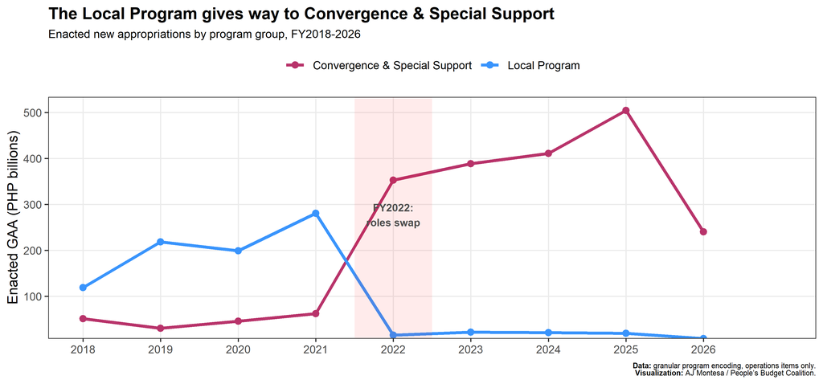

Before the swap, the Local Program ran at **₱119-281B** while Convergence sat at **₱30-62B**. In FY2022 the Local Program fell to **₱15B** and Convergence leapt to **₱353B**; it peaked at **₱504B in FY2025** before the FY2026 flood-driven cut brought it to **₱240B**. Convergence is not a single purpose but a **basket** — it houses the **SIPAG** and **BIP** sub-programs, whose items range from access roads and multi-purpose buildings to, notably, **flood-mitigation structures**. So a large share of what looks like "convergence" or "special support" spending is, underneath, the same district road-and-building-and-drainage work that the Local Program used to carry — now concentrated in one fast-growing, discretionary program.

## 4.3 What Congress Adds To — and Cuts — at the Item Level

Reading Congress's changes (enacted minus proposed) at the **individual item level**, over FY2018-2025 (the FY2026 cycle is treated separately below, as it was reshaped by the flood-control scandal), reveals a consistent pattern: the legislature moves money **out of large, national, strategic works and into district-scale, insertable items**.

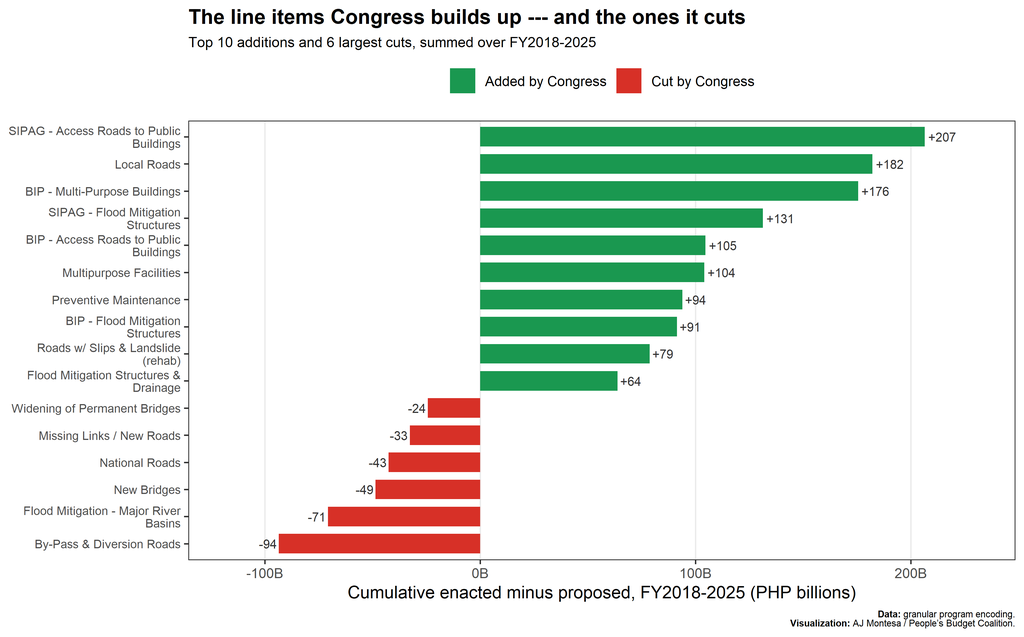

The additions are dominated by **SIPAG and BIP** items — *Access Roads to Public Buildings* (**+₱207B** and **+₱105B**), *Multi-Purpose Buildings* (**+₱176B**), and their *Flood-Mitigation Structures* variants — together with **Local Roads (+₱182B)** and **Multipurpose Facilities (+₱104B)**. The cuts fall on **large national works**: *By-Pass & Diversion Roads* (**-₱94B**), *Flood Mitigation in Major River Basins* (**-₱71B**), *New Bridges* (**-₱49B**), and *National Roads* (**-₱43B**). In other words, the legislature consistently trims the department's big strategic-network and major-river projects and redirects the money into smaller, district-level, more easily-sited items — the granular signature of the Central-Office-to-districts pattern documented in the operating-unit analysis that follows.

Line items Congress most enlarged, cumulative FY2018-2025 (enacted minus proposed)

| Line item | Program | Cumulative addition (PHP B) |
| --- | --- | --- |
| SIPAG - Access Roads to Public Buildings | Convergence and Special Support | 206.5 |
| Local Roads | Local | 182.2 |
| BIP - Multi-Purpose Buildings | Convergence and Special Support | 175.5 |
| SIPAG - Flood Mitigation Structures | Convergence and Special Support | 131.3 |
| BIP - Access Roads to Public Buildings | Convergence and Special Support | 104.6 |
| Multipurpose Facilities | Local | 104.0 |
| Preventive Maintenance | Asset Preservation | 94.0 |
| BIP - Flood Mitigation Structures | Convergence and Special Support | 91.5 |
| Roads w/ Slips & Landslide (rehab) | Asset Preservation | 78.8 |
| Flood Mitigation Structures & Drainage | Flood Management | 63.9 |
| Special Road Fund (MVUC) | Convergence and Special Support | 45.1 |
| Flood Control Structures/ Facilities | Local | 39.2 |
| SIPAG - Multi-Purpose Buildings | Convergence and Special Support | 31.5 |
| SIPAG - Interjurisdictional Roads | Convergence and Special Support | 23.9 |
| SIPAG - Coastal Roads / Causeway | Convergence and Special Support | 22.6 |

## 4.4 The FY2026 Cycle: A Scandal-Driven Revision

FY2026 was unlike any other year in this dataset, and it is why the analysis above stops at FY2025. Midway through 2025 a **flood-control corruption scandal** broke open — ghost projects, kickbacks, and a wave of identically-priced "multi-purpose building" and flood-control insertions. The fallout ran straight through the budget.

The original FY2026 NEP, prepared under then-Secretary Manuel Bonoan and submitted in August 2025, proposed the department's usual large flood-control program. After the scandal, a new Secretary — **Vivencio "Vince" Dizon** — took over in September and submitted an **errata to the NEP**, removing locally-funded flood-control projects on the President's directive. Congress then cut further. The result is a rare three-step collapse: **original NEP → revised NEP → enacted GAA**, all *downward*, the reverse of the department's usual pattern.

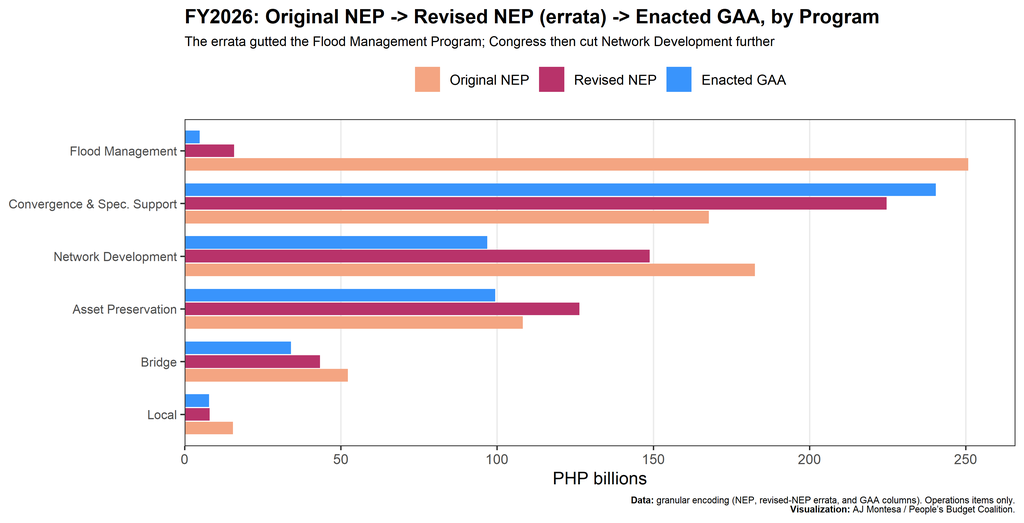

Two moves stand out. The **Flood Management Program was gutted in the errata itself** — from about ₱251B in the original NEP to roughly ₱16B in the revised version, a cut of some ₱235B before Congress even voted — as the flood-mitigation items at the heart of the scandal were pulled. But the revision was not purely subtractive: the **Convergence & Special Support Program actually rose** in the revised NEP (from ~₱168B to ~₱225B) and again in the enacted GAA (~₱240B), even as everything around it shrank. Congress then trained its knife on **Network Development**, cutting it from ~₱149B in the revised NEP to ~₱97B enacted.

So the headline "DPWH budget cut by roughly a third" masks a reshuffle: the scandal removed the flood-control program that had been the vehicle for insertions, but the discretionary **Convergence** basket — which, as shown above, contains its *own* flood-mitigation and district-building items — emerged from the FY2026 process *larger*, not smaller. Whether that represents genuine reform or the same spending under a cleaner-sounding label is exactly the kind of question the granular view is meant to surface.

## 4.5 The Biggest Line Items, and How They've Shifted

Ranking items by **enacted** size shows how the composition of DPWH spending has turned over. In FY2018 the largest items were classic **road and flood works**; by FY2025 the **SIPAG and BIP** items — which barely existed earlier — sit at the very top, alongside the two big flood-mitigation lines.

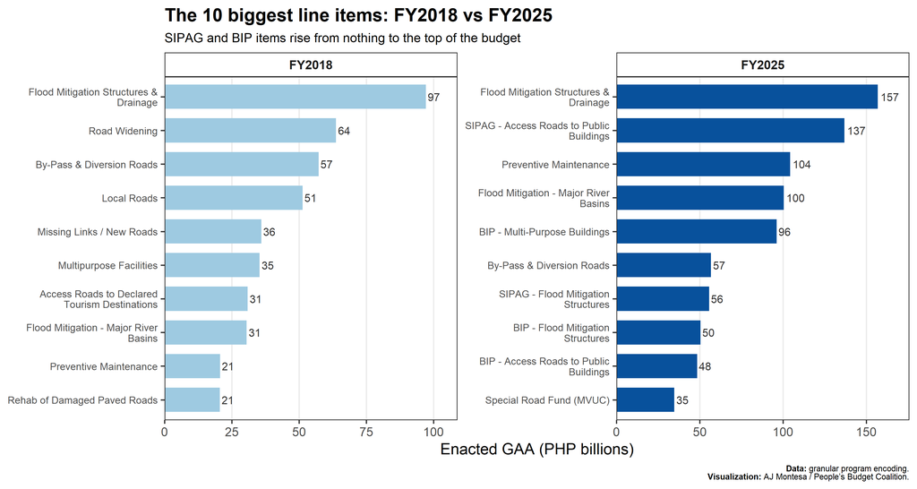

# 5 New Appropriations by Operating Unit

The DPWH disburses its budget across some 200+ **operating units** — the Central Office, regional offices, and district engineering offices (DEOs). The data run from the **FY2014 budget** through **FY2026**, spanning the 16th through 20th Congresses — the Aquino, Duterte, and Marcos administrations, and **seven House Speakers**. The series is now complete across all thirteen fiscal years; the GAA encoded for **2019** reflects the budget *after* the President's ₱95.4-billion line-item veto (isolated below). That span lets us trace how district money has moved between proposal and enactment across administrations. Amounts are in **pesos**, rescaled to **PHP billions**.

Because the realignments that move money toward district engineering offices are made on the House floor, the relevant political actor is often the **Speaker of the day** as much as the sitting President. **Seven** Speakers presided over the budgets in this window; their terms and the fiscal-year budgets each steered to passage are below.

House Speakers presiding over the DPWH budgets analysed here. *FY2019's encoded GAA is post-veto; the ₱95.4B line-item veto that year fell mostly on the Central Office (see the veto chart below).

| Speaker | Term began | Congress | FY budgets | Administration |
| --- | --- | --- | --- | --- |
| Feliciano Belmonte Jr. | 22 Jul 2013 | 16th | FY2014-2016 | Aquino |
| Pantaleon Alvarez | 25 Jul 2016 | 17th | FY2017-2018 | Duterte |
| Gloria Macapagal Arroyo | 23 Jul 2018 | 17th | FY2019* | Duterte |
| Alan Peter Cayetano | 22 Jul 2019 | 18th | FY2020 | Duterte |
| Lord Allan Velasco | 12 Oct 2020 | 18th | FY2021-2022 | Duterte |
| Martin Romualdez | 25 Jul 2022 | 19th | FY2023-2025 | Marcos |
| Faustino "Bojie" Dy III | 17 Sep 2025 | 20th | FY2026 | Marcos |

## 5.1 Most of the Money Sits in the Central Office

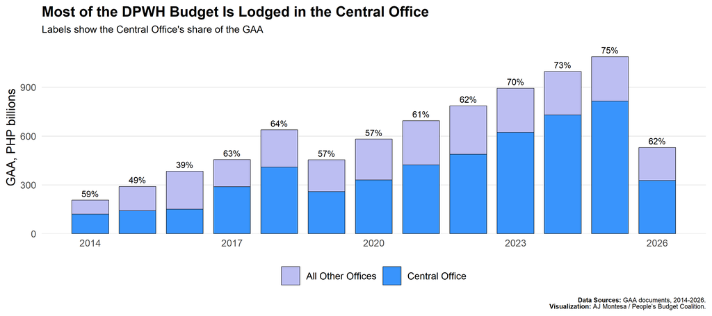

DPWH GAA: Central Office vs all other operating units, PHP billions

| FY | Central Office (B) | All Other Offices (B) | Total (B) | Central share |
| --- | --- | --- | --- | --- |
| 2014 | 121.2 | 85.4 | 206.6 | 58.6% |
| 2015 | 141.5 | 148.9 | 290.5 | 48.7% |
| 2016 | 150.4 | 233.9 | 384.3 | 39.1% |
| 2017 | 288.7 | 166.0 | 454.7 | 63.5% |
| 2018 | 409.5 | 228.4 | 637.9 | 64.2% |
| 2019 | 259.3 | 194.8 | 454.1 | 57.1% |
| 2020 | 330.1 | 250.8 | 580.9 | 56.8% |
| 2021 | 422.6 | 272.2 | 694.8 | 60.8% |
| 2022 | 487.6 | 298.1 | 785.7 | 62.1% |
| 2023 | 622.5 | 270.6 | 893.1 | 69.7% |
| 2024 | 729.1 | 267.7 | 996.8 | 73.1% |
| 2025 | 814.7 | 273.0 | 1,087.7 | 74.9% |
| 2026 | 326.6 | 203.0 | 529.6 | 61.7% |

## 5.2 From Proposal to Law: Central Office to the Districts

The executive's proposal concentrates the budget in the Central Office even more than the enacted law does. In pesos the redistribution is large and one-directional: Congress channels tens — and, in recent years, hundreds — of billions toward district engineering offices between the proposal and the enacted law, in **every year on record**, while the Central Office is cut in most (first chart). In share terms the pattern is cleaner still: in every year (2014-2026) the Central Office's share of new appropriations *falls* from NEP to GAA while the districts' share *rises* — a swing reaching nearly **30 percentage points** in 2021 and 2023, when the proposal parked almost the entire budget centrally (second chart). Congress, in other words, systematically moves money toward named district engineering offices; this is the redistribution that the office-by-office realignment analysis below traces in detail.

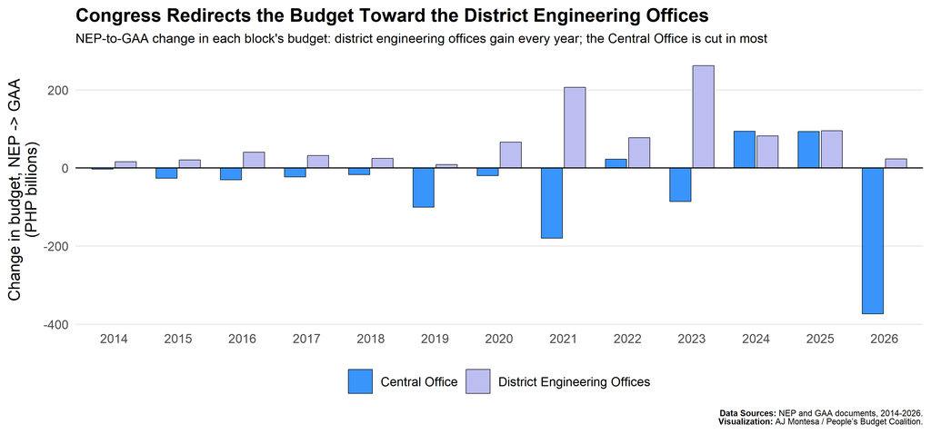

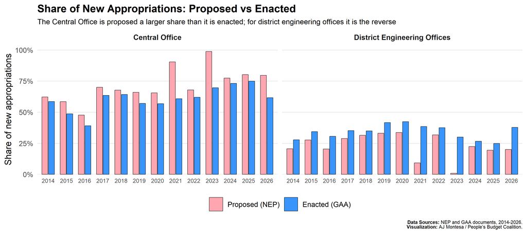

Two of those Central cuts come with an asterisk, because they are not really Congress's doing. The operating-unit GAA encoded for **2019** is the budget *after* the President's **₱95.4-billion line-item veto** — the largest in recent memory — and that veto landed overwhelmingly on the Central Office (**₱74B** of the ₱95B struck, versus ₱21B across the districts). That is why 2019 shows such a deep Central cut above. Congress's own pre-veto budget was routine: it trimmed the Central Office by roughly **₱26B** and added about **₱30B** to the districts, the usual direction of travel. The chart below splits what Congress actually passed into the part that survived the veto (blue) and the part the President struck out (grey); the diamonds mark the President's original proposal (NEP). Because the veto hit the Central Office hardest, it paradoxically *raised* the district share of the final budget (from 38% pre-veto to 42% enacted).

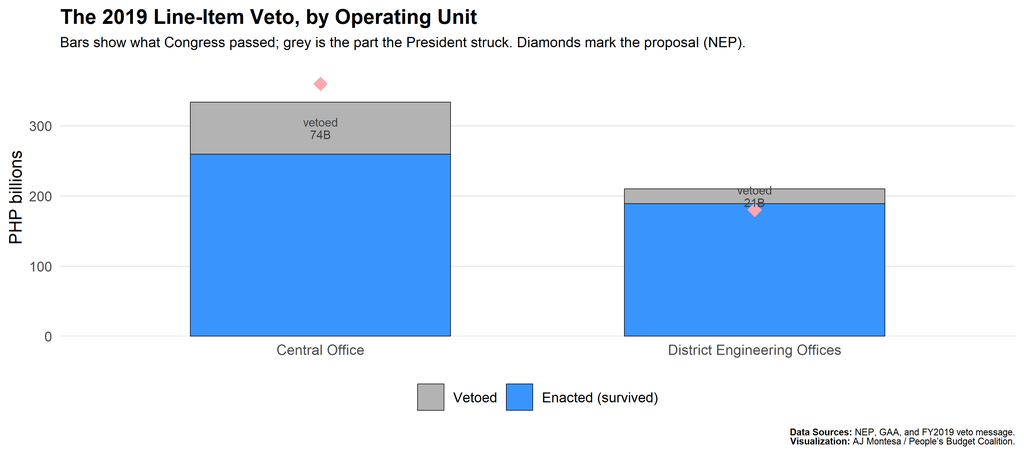

## 5.3 The Largest District Engineering Offices in Each Congress

Which districts command the biggest budgets is not fixed — it shifts from one Congress to the next as offices are created, priorities move, and realignment patterns change. The charts and tables below rank the **top 20 district engineering offices in each Congress**, showing both what the Executive **proposed (NEP)** and what was finally **enacted (GAA)**, summed over that Congress's budgets. Reading down the Congresses gives a sense of which parts of the country the DPWH budget has most favoured over time.

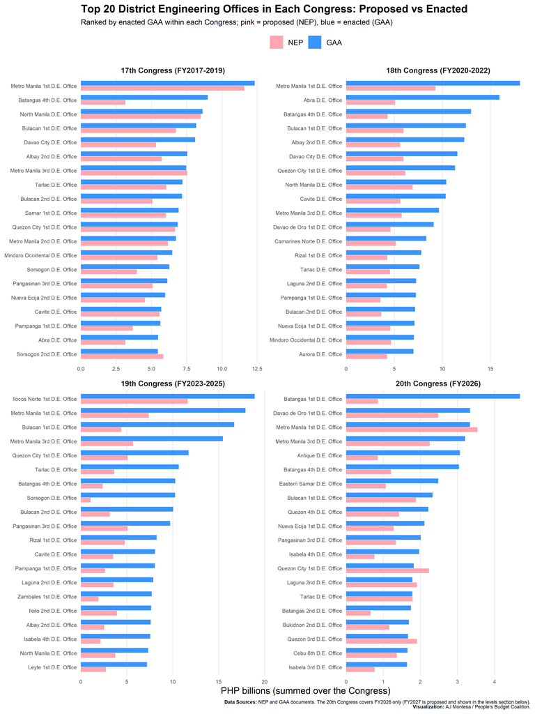

### 5.3.1 Top 20 tables, by Congress

The same rankings in full, with the exact proposed and enacted amounts and the net addition Congress made on enactment. Each table is the **top 20 offices by enacted GAA** for that Congress.

#### 5.3.1.1 17th Congress (FY2017-2019)

Top 20 District Engineering Offices by Enacted GAA --- 17th Congress (FY2017-2019)

| Rank | District Engineering Office | NEP (PHP B) | GAA (PHP B) | Net add (PHP B) |
| --- | --- | --- | --- | --- |
| 1 | Metro Manila 1st | 11.59 | 12.33 | 0.74 |
| 2 | Batangas 4th | 3.16 | 9.00 | 5.83 |
| 3 | North Manila | 8.50 | 8.63 | 0.13 |
| 4 | Bulacan 1st | 6.75 | 8.17 | 1.43 |
| 5 | Davao City | 5.33 | 8.10 | 2.77 |
| 6 | Albay 2nd | 5.73 | 7.55 | 1.82 |
| 7 | Metro Manila 3rd | 7.55 | 7.47 | -0.07 |
| 8 | Tarlac | 6.06 | 7.21 | 1.16 |
| 9 | Bulacan 2nd | 5.08 | 7.17 | 2.09 |
| 10 | Samar 1st | 6.04 | 6.93 | 0.89 |
| 11 | Quezon City 1st | 6.68 | 6.87 | 0.19 |
| 12 | Metro Manila 2nd | 6.17 | 6.75 | 0.58 |
| 13 | Mindoro Occidental | 5.44 | 6.48 | 1.05 |
| 14 | Sorsogon | 3.97 | 6.27 | 2.30 |
| 15 | Pangasinan 3rd | 5.09 | 6.13 | 1.04 |
| 16 | Nueva Ecija 2nd | 4.55 | 5.97 | 1.43 |
| 17 | Cavite | 5.58 | 5.70 | 0.12 |
| 18 | Pampanga 1st | 3.68 | 5.63 | 1.95 |
| 19 | Abra | 3.16 | 5.48 | 2.31 |
| 20 | Sorsogon 2nd | 5.85 | 5.46 | -0.39 |

#### 5.3.1.2 18th Congress (FY2020-2022)

Top 20 District Engineering Offices by Enacted GAA --- 18th Congress (FY2020-2022)

| Rank | District Engineering Office | NEP (PHP B) | GAA (PHP B) | Net add (PHP B) |
| --- | --- | --- | --- | --- |
| 1 | Metro Manila 1st | 9.29 | 18.07 | 8.78 |
| 2 | Abra | 5.09 | 15.94 | 10.85 |
| 3 | Batangas 4th | 4.31 | 12.99 | 8.69 |
| 4 | Bulacan 1st | 5.96 | 12.46 | 6.49 |
| 5 | Albay 2nd | 5.60 | 12.28 | 6.68 |
| 6 | Davao City | 5.96 | 11.57 | 5.61 |
| 7 | Quezon City 1st | 6.15 | 11.32 | 5.17 |
| 8 | North Manila | 6.92 | 10.42 | 3.50 |
| 9 | Cavite | 5.64 | 10.34 | 4.70 |
| 10 | Metro Manila 3rd | 5.77 | 9.65 | 3.88 |
| 11 | Davao de Oro 1st | 4.62 | 9.09 | 4.48 |
| 12 | Camarines Norte | 5.15 | 8.34 | 3.18 |
| 13 | Rizal 1st | 4.28 | 7.81 | 3.53 |
| 14 | Tarlac | 4.55 | 7.63 | 3.08 |
| 15 | Laguna 2nd | 4.24 | 7.27 | 3.04 |
| 16 | Pampanga 1st | 3.57 | 7.26 | 3.69 |
| 17 | Bulacan 2nd | 3.64 | 7.16 | 3.52 |
| 18 | Nueva Ecija 1st | 4.60 | 7.11 | 2.51 |
| 19 | Mindoro Occidental | 4.66 | 7.04 | 2.38 |
| 20 | Aurora | 4.24 | 7.00 | 2.76 |

#### 5.3.1.3 19th Congress (FY2023-2025)

Top 20 District Engineering Offices by Enacted GAA --- 19th Congress (FY2023-2025)

| Rank | District Engineering Office | NEP (PHP B) | GAA (PHP B) | Net add (PHP B) |
| --- | --- | --- | --- | --- |
| 1 | Ilocos Norte 1st | 11.63 | 18.93 | 7.30 |
| 2 | Metro Manila 1st | 7.41 | 17.92 | 10.52 |
| 3 | Bulacan 1st | 4.40 | 16.70 | 12.29 |
| 4 | Metro Manila 3rd | 5.68 | 15.47 | 9.79 |
| 5 | Quezon City 1st | 5.09 | 11.73 | 6.64 |
| 6 | Tarlac | 3.64 | 10.66 | 7.02 |
| 7 | Batangas 4th | 2.37 | 10.28 | 7.91 |
| 8 | Sorsogon | 1.06 | 10.26 | 9.20 |
| 9 | Bulacan 2nd | 3.14 | 10.04 | 6.90 |
| 10 | Pangasinan 3rd | 5.10 | 9.72 | 4.63 |
| 11 | Rizal 1st | 4.78 | 8.25 | 3.47 |
| 12 | Cavite | 3.51 | 8.07 | 4.56 |
| 13 | Pampanga 1st | 2.64 | 8.06 | 5.42 |
| 14 | Laguna 2nd | 3.56 | 7.88 | 4.33 |
| 15 | Zambales 1st | 1.91 | 7.72 | 5.81 |
| 16 | Iloilo 2nd | 3.92 | 7.66 | 3.73 |
| 17 | Albay 2nd | 2.55 | 7.59 | 5.05 |
| 18 | Isabela 4th | 2.14 | 7.55 | 5.41 |
| 19 | North Manila | 3.76 | 7.32 | 3.56 |
| 20 | Leyte 1st | 2.73 | 7.19 | 4.47 |

#### 5.3.1.4 20th Congress (FY2026)

Top 20 District Engineering Offices by Enacted GAA --- 20th Congress (FY2026)

| Rank | District Engineering Office | NEP (PHP B) | GAA (PHP B) | Net add (PHP B) |
| --- | --- | --- | --- | --- |
| 1 | Batangas 1st | 0.86 | 4.69 | 3.83 |
| 2 | Davao de Oro 1st | 2.48 | 3.34 | 0.85 |
| 3 | Metro Manila 1st | 3.54 | 3.34 | -0.20 |
| 4 | Metro Manila 3rd | 2.25 | 3.21 | 0.95 |
| 5 | Antique | 0.85 | 3.07 | 2.21 |
| 6 | Batangas 4th | 1.21 | 3.04 | 1.83 |
| 7 | Eastern Samar | 1.07 | 2.48 | 1.41 |
| 8 | Bulacan 1st | 1.88 | 2.33 | 0.45 |
| 9 | Quezon 4th | 1.42 | 2.21 | 0.79 |
| 10 | Nueva Ecija 1st | 1.28 | 2.11 | 0.83 |
| 11 | Pangasinan 3rd | 1.34 | 2.01 | 0.67 |
| 12 | Isabela 4th | 0.76 | 1.97 | 1.21 |
| 13 | Quezon City 1st | 2.23 | 1.82 | -0.41 |
| 14 | Laguna 2nd | 1.91 | 1.79 | -0.13 |
| 15 | Tarlac | 1.79 | 1.79 | -0.01 |
| 16 | Batangas 2nd | 0.66 | 1.75 | 1.08 |
| 17 | Bukidnon 2nd | 1.16 | 1.69 | 0.53 |
| 18 | Quezon 3rd | 1.91 | 1.66 | -0.25 |
| 19 | Cebu 6th | 1.37 | 1.65 | 0.29 |
| 20 | Isabela 3rd | 0.77 | 1.64 | 0.87 |

## 5.4 Top District Engineering Offices, by Size and by Realignment

Setting the Central Office aside, two questions matter for the hearings: which district engineering offices command the **largest budgets**, and how much of each budget was in the President's proposal versus added on enactment. The first two charts break the largest offices into what was **proposed** (grey) and what Congress **added** on enactment — shown as a single total (purple) in the first chart, then with the additions split between the **Duterte** (red) and **Marcos** (blue) administrations in the second. The third chart ranks offices by the realignments they received within each Congress — now reaching back to the 16th (the three Aquino-era budgets) — coloured by the fiscal year that delivered each addition, with the amounts the President later vetoed shown in grey — the FY2019 vetoes on the 17th-Congress bars (medium grey) and the smaller FY2025 vetoes on the 19th (dark grey).

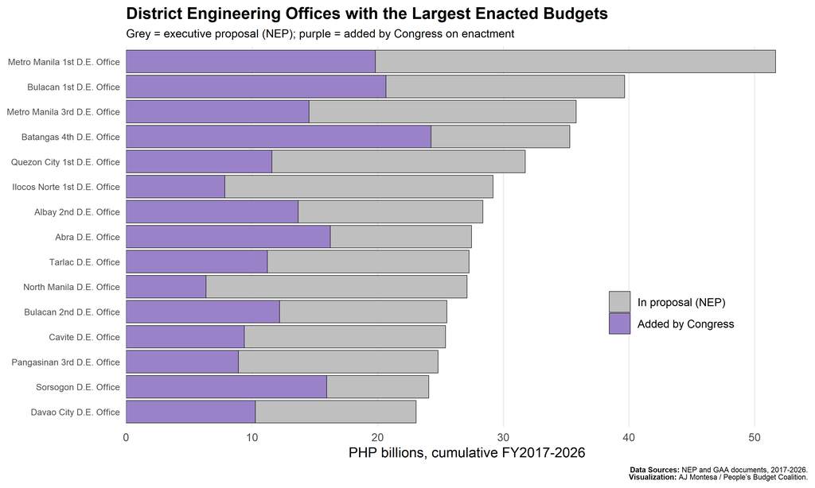

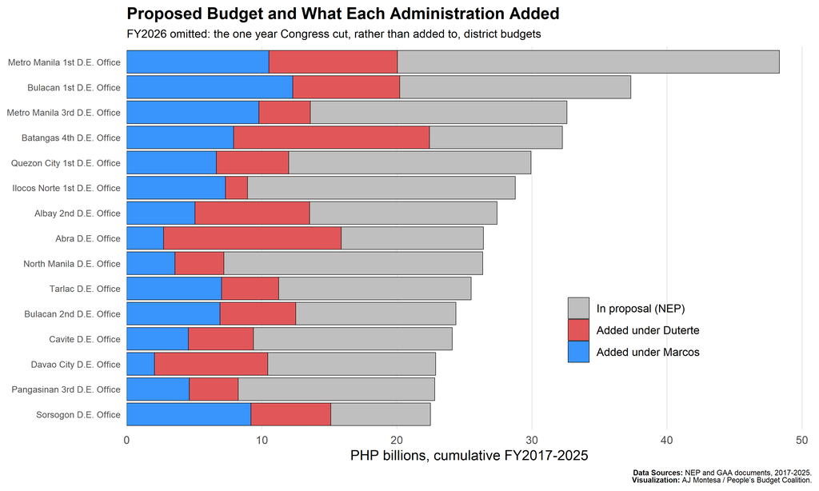

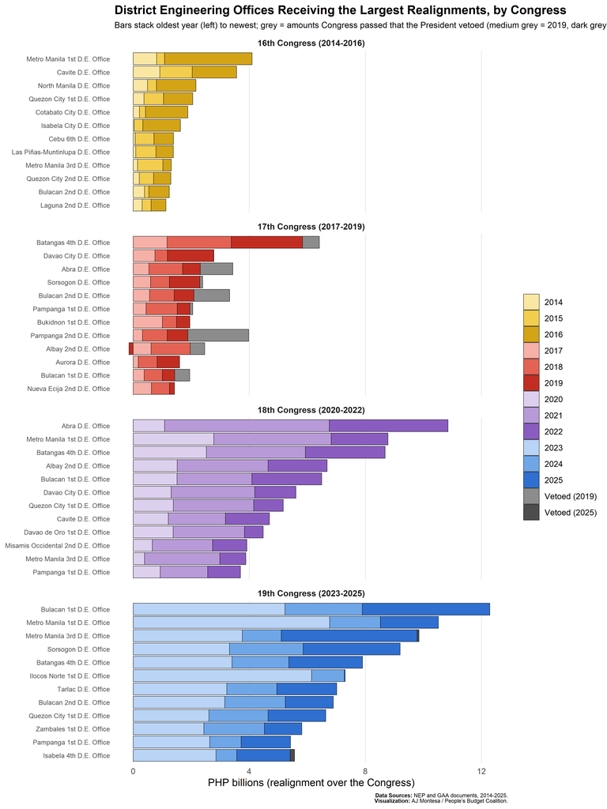

The realignment matrix below splits each of the most-favoured offices' realignments between the **Duterte** and **Marcos** administrations — making clear, for instance, that **Abra**'s windfalls came overwhelmingly under Duterte (2017-2022), while others (e.g. **Bulacan 1st**, **Tarlac**) lean Marcos.

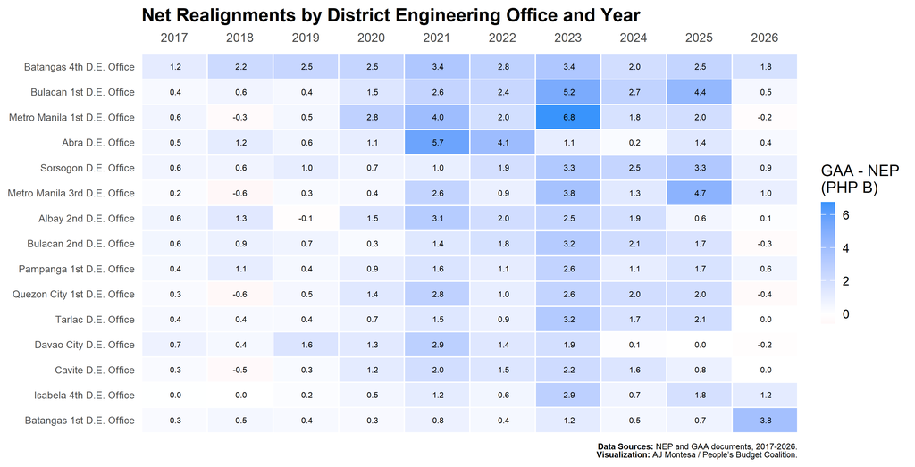

Top 20 D.E. Offices by total NEP-to-GAA realignment, FY2017-2026 (PHP billions)

| Office | Duterte (B) | Marcos (B) | Total (B) |
| --- | --- | --- | --- |
| Batangas 4th D.E. Office | 14.5 | 9.7 | 24.3 |
| Bulacan 1st D.E. Office | 7.9 | 12.7 | 20.7 |
| Metro Manila 1st D.E. Office | 9.5 | 10.3 | 19.8 |
| Abra D.E. Office | 13.2 | 3.1 | 16.2 |
| Sorsogon D.E. Office | 5.9 | 10.1 | 16.0 |
| Metro Manila 3rd D.E. Office | 3.8 | 10.7 | 14.6 |
| Albay 2nd D.E. Office | 8.5 | 5.2 | 13.7 |
| Bulacan 2nd D.E. Office | 5.6 | 6.6 | 12.2 |
| Pampanga 1st D.E. Office | 5.6 | 6.0 | 11.7 |
| Quezon City 1st D.E. Office | 5.4 | 6.2 | 11.6 |
| Tarlac D.E. Office | 4.2 | 7.0 | 11.2 |
| Davao City D.E. Office | 8.4 | 1.9 | 10.3 |
| Cavite D.E. Office | 4.8 | 4.6 | 9.4 |
| Isabela 4th D.E. Office | 2.5 | 6.6 | 9.1 |
| Batangas 1st D.E. Office | 2.7 | 6.2 | 9.0 |
| Pangasinan 3rd D.E. Office | 3.6 | 5.3 | 8.9 |
| Zambales 1st D.E. Office | 2.6 | 6.0 | 8.6 |
| Iloilo 2nd D.E. Office | 4.2 | 4.1 | 8.3 |
| Mindoro Occidental D.E. Office | 3.4 | 4.8 | 8.2 |
| Laguna 2nd D.E. Office | 3.9 | 4.2 | 8.1 |

## 5.5 Which District Engineering Offices Merit a Closer Look?

Rather than single out any one region, this section applies a transparent screen to *every* district engineering office and lets the data nominate which ones deserve a deeper dive. Each office is scored on four independent signals over FY2017-2026 (the Duterte and Marcos administrations):

- **Size** — it is among the ten largest recipients of realignments;
- **Intensity** — realignments make up at least 60% of the office's enacted budget;
- **Persistence** — it received a realignment in at least eight of the ten years;
- **Tilt** — the office's realignment totals under the two administrations differ by at least ₱4B.

Every signal builds on the same yearly *realignment* — the gap between an office's enacted and proposed budget, **GAA − NEP** (in ₱B). The tilt signal sums those yearly realignments within each administration and takes the difference between the two totals:

**admin tilt = (total GAA − NEP across FY2017-2022) − (total GAA − NEP across FY2023-2026),**

i.e. the office's total Duterte-era realignment minus its total Marcos-era realignment. A positive tilt means the office gained more under Duterte and is shown **red** in the chart below; a negative tilt means it gained more under Marcos and is shown **blue**; values near zero are grey.

Offices that trip several signals at once are the natural candidates for scrutiny.

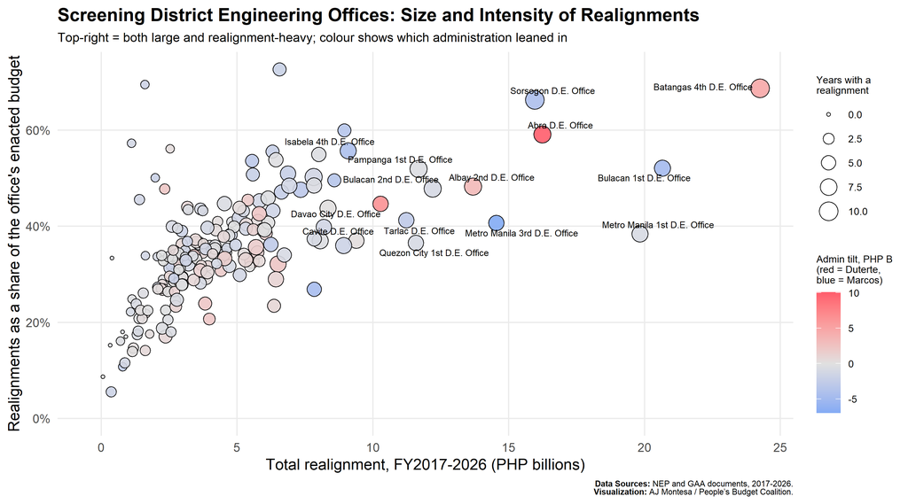

The vertical axis starts at 0% and extends only as far as the data require. Two sets of offices fall outside it. First, 1 newly-created district engineering offices had **no proposed budget** (NEP = 0) anywhere in the FY2017-2026 window, so their realignment share is 100% by construction — money Congress provided where the executive proposed nothing — and they are excluded from the scatter: Cavite 5th D.E. Office. Second, 5 very small offices fall *below* 0%, where the cumulative *enacted* budget came in under the proposal (a net trim rather than the padding that dominates the chart): Davao City 3rd D.E. Office (-240%); Davao del Norte 2nd D.E. Office (-43%); Bukidnon 4th D.E. Office (-32%); Southern Leyte 2nd D.E. Office (-18%); Zamboanga City 2nd D.E. Office (-14%). Because these offices are tiny, a modest peso cut reads as a large negative share, so those values are denominator artefacts more than meaningful signals.

District engineering offices flagged for a closer look, sorted by number of signals then size

| Office | Realignment (B) | Realignment share | Years realigned | Duterte (B) | Marcos (B) | Flags | Signals |
| --- | --- | --- | --- | --- | --- | --- | --- |
| Batangas 4th D.E. Office | 24.3 | 69% | 10/10 | 14.5 | 9.7 | 4 | large; realignment-heavy; every year; Duterte-leaning |
| Sorsogon D.E. Office | 16.0 | 66% | 10/10 | 5.9 | 10.1 | 4 | large; realignment-heavy; every year; Marcos-leaning |
| Abra D.E. Office | 16.2 | 59% | 8/10 | 13.2 | 3.1 | 3 | large; every year; Duterte-leaning |
| Bulacan 1st D.E. Office | 20.7 | 52% | 7/10 | 7.9 | 12.7 | 2 | large; Marcos-leaning |
| Metro Manila 3rd D.E. Office | 14.6 | 41% | 6/10 | 3.8 | 10.7 | 2 | large; Marcos-leaning |
| Albay 2nd D.E. Office | 13.7 | 48% | 8/10 | 8.5 | 5.2 | 2 | large; every year |
| Bulacan 2nd D.E. Office | 12.2 | 48% | 8/10 | 5.6 | 6.6 | 2 | large; every year |
| Pampanga 1st D.E. Office | 11.7 | 52% | 8/10 | 5.6 | 6.0 | 2 | large; every year |
| Metro Manila 1st D.E. Office | 19.8 | 38% | 7/10 | 9.5 | 10.3 | 1 | large |
| Quezon City 1st D.E. Office | 11.6 | 36% | 6/10 | 5.4 | 6.2 | 1 | large |
| Davao City D.E. Office | 10.3 | 45% | 6/10 | 8.4 | 1.9 | 1 | Duterte-leaning |
| Isabela 4th D.E. Office | 9.1 | 56% | 7/10 | 2.5 | 6.6 | 1 | Marcos-leaning |
| Ilocos Norte 1st D.E. Office | 7.8 | 27% | 5/10 | 1.6 | 6.2 | 1 | Marcos-leaning |
| Batangas 2nd D.E. Office | 7.8 | 50% | 8/10 | 3.2 | 4.6 | 1 | every year |
| Cebu 7th D.E. Office | 6.6 | 73% | 4/10 | 2.3 | 4.3 | 1 | realignment-heavy |

# 6 The FY 2027 Proposal

The FY 2027 National Expenditure Program is the live budget document now before Congress — the one advocates can still shape. The proposal's figures already run through the tables and charts in the sections above; this section draws them together in one place: the proposal's overall size, its distribution **by program** and **by district engineering office**, and how it compares to the two most useful benchmarks — what the Executive proposed for FY 2026 (the previous **NEP**) and what Congress actually enacted (the previous **GAA**).

## 6.1 FY 2027 in Context: Comparison with FY 2026

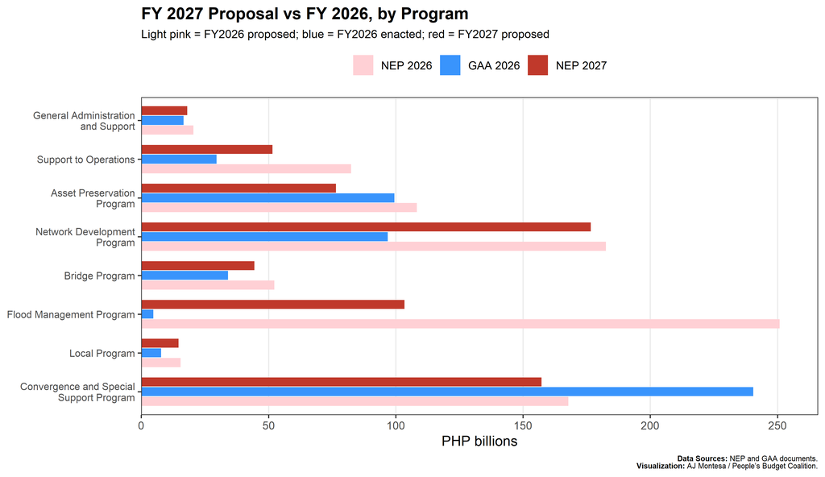

Read program by program, the FY 2027 proposal looks far more like the FY 2026 *proposal* than the FY 2026 *enacted* budget — the Executive is, in effect, re-proposing much of what Congress rearranged on the way to the 2026 GAA:

- **Flood Management**, gutted to just **₱4.8B** in the 2026 GAA, is restored to **₱103.5B** in the FY 2027 proposal (though still below its ₱250.8B FY2026 NEP).
- **Network Development**, which Congress cut to **₱96.8B** on enactment, returns to **₱176.6B** — close to its original FY2026 proposal.
- The **Convergence and Special Support Program** — which Congress *inflated* to **₱240.5B** on enactment — is proposed back down at **₱157.3B**, roughly its FY2026 proposed level.

The full comparison, with the proposed change measured against the enacted 2026 budget (the current baseline):

FY 2027 Proposed New Appropriations vs FY 2026, by Program (PHP billions)

| Program | NEP 2026 | GAA 2026 | NEP 2027 | Chg. vs 2026 GAA |
| --- | --- | --- | --- | --- |
| Network Development Program | 182.5 | 96.8 | 176.6 | 79.8 |
| Convergence and Special Support Program | 167.8 | 240.5 | 157.3 | -83.2 |
| Flood Management Program | 250.8 | 4.8 | 103.5 | 98.7 |
| Asset Preservation Program | 108.3 | 99.4 | 76.5 | -22.9 |
| Support to Operations | 82.4 | 29.6 | 51.6 | 22.0 |
| Bridge Program | 52.3 | 34.1 | 44.4 | 10.4 |
| General Administration and Support | 20.5 | 16.6 | 18.1 | 1.5 |
| Local Program | 15.4 | 7.8 | 14.6 | 6.8 |

## 6.2 By Program: Proposed and Enacted Levels

Zooming in on the programs, it helps to see the **overall levels** the Executive proposes and the legislature enacts — the raw distribution of pesos across programs, and where the **FY 2027 proposal** places them relative to the recent past.

At the department level, the FY 2027 NEP proposes **₱642.6B** — a marked step down from the ₱880B proposed for 2026 and the ₱1,087.7B *enacted* for 2025 (the 2025 figure is the post-veto total; see the veto section). The proposed-versus-enacted totals over the full window make the swings plain:

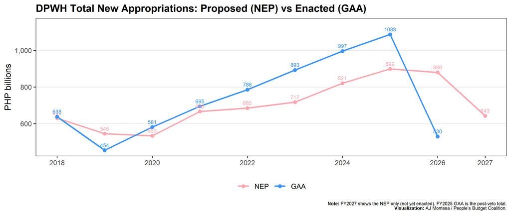

The enacted budget ran *above* the proposal every year from 2020 to 2025 — a legislature adding to the President's plan — until FY2026, when the enacted total fell far *below* the proposal (the ₱246B flood-control cut). The FY2027 proposal resets the level near ₱643B.

**How is the FY 2027 proposal distributed across programs?** Two programs account for more than half of it: Network Development (₱176.6B, 27%) and the Convergence and Special Support Program (₱157.3B, 25%) — the latter historically the *discretionary* program that Congress inflated through realignments, now proposed at a high level in the Executive's own document.

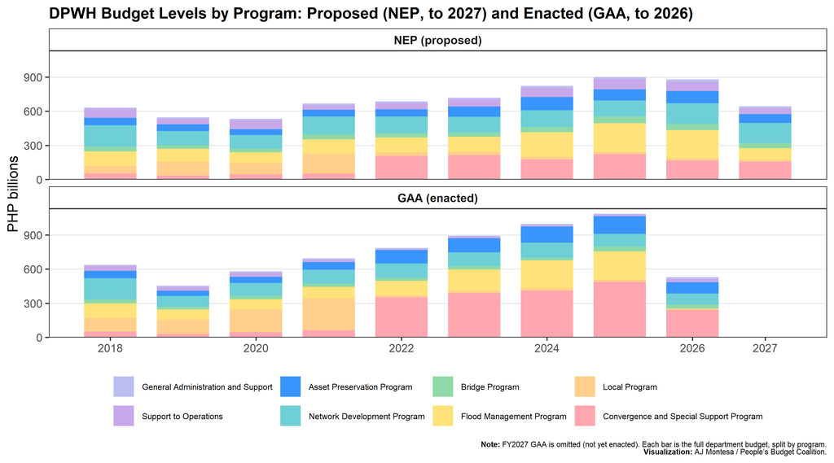

FY 2027 Proposed New Appropriations by Program (NEP)

| Program | NEP 2027 (PHP B) | Share of proposal |
| --- | --- | --- |
| Network Development Program | 176.6 | 27.5% |
| Convergence and Special Support Program | 157.3 | 24.5% |
| Flood Management Program | 103.5 | 16.1% |
| Asset Preservation Program | 76.5 | 11.9% |
| Support to Operations | 51.6 | 8.0% |
| Bridge Program | 44.4 | 6.9% |
| General Administration and Support | 18.1 | 2.8% |
| Local Program | 14.6 | 2.3% |

## 6.3 Inside the Proposal: The Biggest Line Items

Applying the same granular lens to the **FY 2027 proposal** shows what the Executive is prioritising *within* the programs. The largest proposed items are a telling mix of the national works Congress usually trims and the district-oriented items it usually adds.

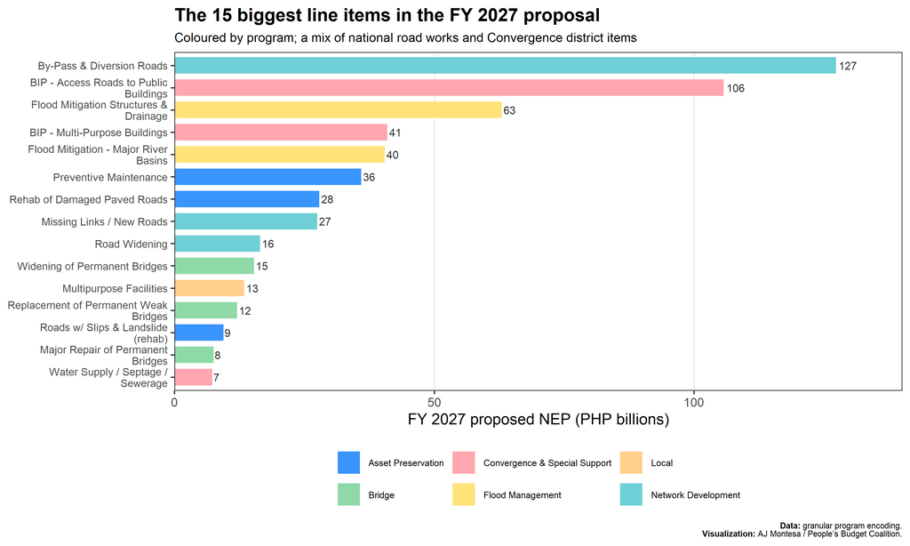

## 6.4 By District Engineering Office: The Proposed Distribution

Having seen how Congress has historically built up district budgets, it is worth turning the same geographic lens on the **FY 2027 proposal**. Its starting distribution across operating units is strikingly centralized — a reminder that the district-level build-up documented above happens *after* the proposal, not in it.

Of the ₱642.6B proposed for FY 2027, **₱510.0B (79%) sits in the Central Office** and only **₱129.7B (20%) is distributed across the 198 district engineering offices** (the small remainder is in regional and other units). That 79/20 split is the raw material Congress works on: the district-level build-up that defines DPWH's budget politics happens *later*, in the move from proposal to enacted law.

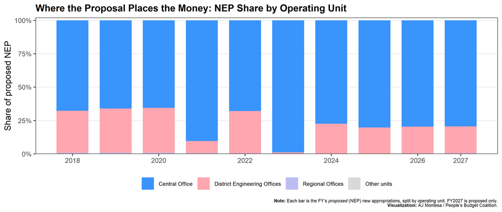

**Which districts fare best in the proposal?** Even within the 20% that is pre-allocated to named districts, the FY2027 NEP is concentrated: the top office is proposed ₱3.5B while the median district gets a fraction of that.

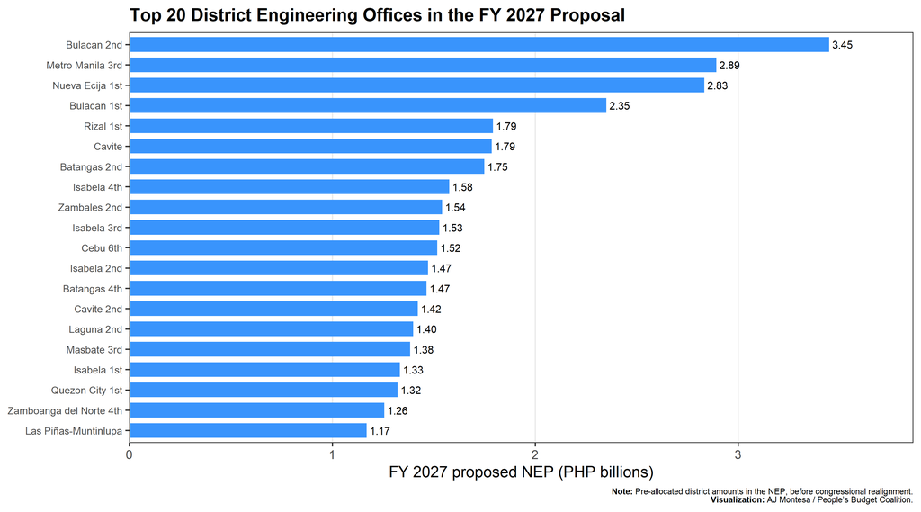

The offices proposed the most in FY2027 — Bulacan 2nd (₱3.5B), Metro Manila 3rd (₱2.9B), Nueva Ecija 1st (₱2.8B) — are a mix of high-population and infrastructure-heavy districts. But the more important point for scrutiny is the gap between this proposed geography and the *enacted* one: as the realignment analysis above shows, Congress adds heavily to district offices during deliberations, so the enacted distribution of DPWH money will look very different from this proposal.

# 7 The Line-Item Vetoes: 2019 and 2025

Twice in this window the President reached past Congress's realignments and struck enacted amounts out of the DPWH budget by **line-item veto** — in **FY2019 (₱95.4B)** and again in **FY2025 (₱26.1B)**. In both years the pattern was the same: Congress inflated the proposal (heavily in 2019's Local Program, and in 2025's Convergence and Flood programs), and the President then vetoed a large block of it, almost all from the **Central Office**. The enacted GAA used throughout this report is the **post-veto** figure in both years.

## 7.1 The 2019 Veto (₱95.4B)

In FY2019, Congress raised the DPWH's New Appropriations only modestly in aggregate (from a **₱544.5B** proposal to a **₱549.4B** legislated total) but **heavily reallocated** the money — above all into the Local Program. The President then exercised **line-item vetoes worth ₱95.37B**, almost all of it from that program, bringing the enacted GAA down to **₱454.0B** (the NEP-to-GAA dip visible back in Section 1). The three stages below are what the President **proposed** (NEP), what Congress **legislated** (the pre-veto total), and what was finally **enacted** after the line-item veto.

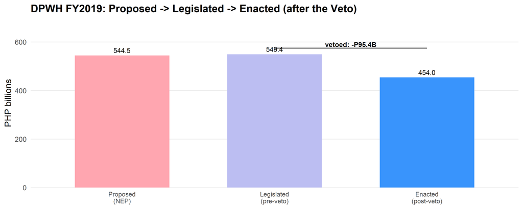

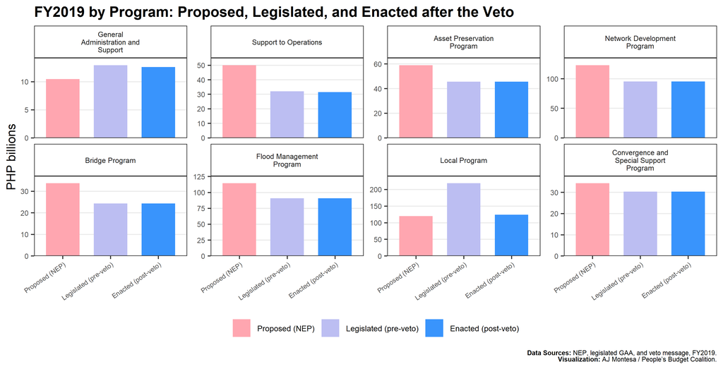

The veto was overwhelmingly a **Local Program** event: only that program (plus token amounts in the two overhead lines) shows a legislated (pre-veto) bar towering over the enacted level. Unpacking the vetoed line items by **type of work** and by **engineering office** shows where the realigned money had been parked:

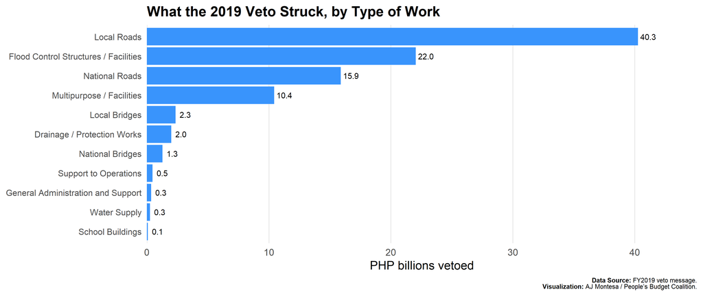

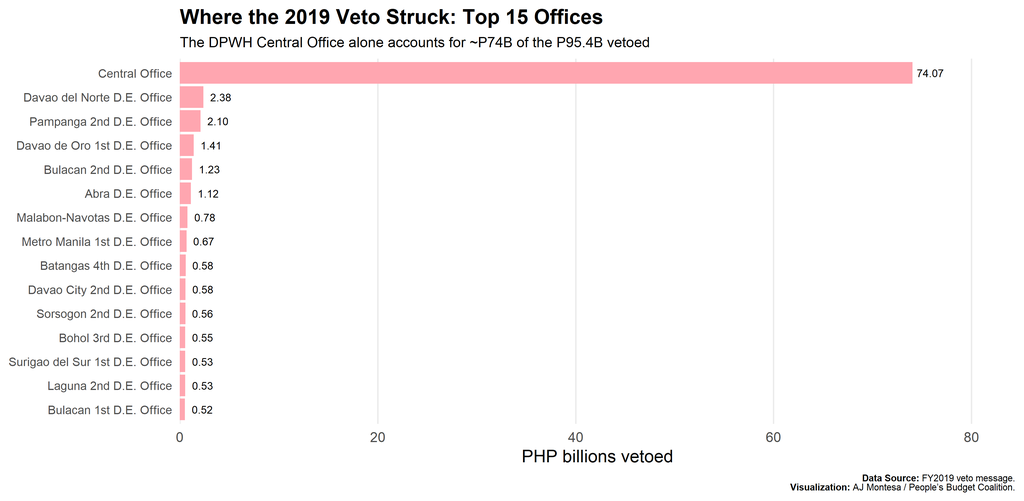

FY2019 DPWH: proposed, legislated (pre-veto), vetoed, and enacted (post-veto) --- PHP billions

| Program | Proposed (NEP) | Legislated (pre-veto) | Vetoed | Enacted (post-veto) |
| --- | --- | --- | --- | --- |
| General Administration and Support | 10.5 | 12.9 | 0.3 | 12.6 |
| Support to Operations | 50.0 | 31.9 | 0.5 | 31.5 |
| Asset Preservation Program | 59.0 | 45.5 | 0.0 | 45.5 |
| Network Development Program | 122.9 | 95.3 | 0.0 | 95.3 |
| Bridge Program | 33.7 | 24.3 | 0.0 | 24.3 |
| Flood Management Program | 114.3 | 90.7 | 0.0 | 90.7 |
| Local Program | 119.9 | 218.4 | 94.6 | 123.9 |
| Convergence and Special Support Program | 34.3 | 30.3 | 0.0 | 30.3 |
| DPWH TOTAL | 544.5 | 549.4 | 95.4 | 454.0 |

FY2019 vetoed line items, by type of work

| Activity | Vetoed (PHP B) | Share of veto |
| --- | --- | --- |
| Local Roads | 40.27 | 42.2% |
| Flood Control Structures / Facilities | 22.05 | 23.1% |
| National Roads | 15.89 | 16.7% |
| Multipurpose / Facilities | 10.43 | 10.9% |
| Local Bridges | 2.34 | 2.5% |
| Drainage / Protection Works | 1.99 | 2.1% |
| National Bridges | 1.27 | 1.3% |
| Support to Operations | 0.46 | 0.5% |
| General Administration and Support | 0.35 | 0.4% |
| Water Supply | 0.25 | 0.3% |
| School Buildings | 0.08 | 0.1% |